# FMS Fase 4 - Soja

Octavio Deliberato Neto

20/06/2019

## Introdução

Este relatório descreve as etapas executadas para concluir a Fase 4 do Projeto FMS - Estimativa da Produtividade de Culturas de Soja, e mostra também os códigos correspondentes em R.

Em relação às etapas anteriores do projeto, notam-se as seguintes diferenças:

- As culturas de milho foram retiradas do escopo do projeto
- O código dado a cada semente foi usado integralmente, e não somente o primeiro caractere, como nas etapas anteriores
- Em consequência do item anterior, as sementes com baixa participação no conjunto de dados, cujo critério será detalhado posteriormente, foram eliminadas da análise. Esse critério constituiu premissa do projeto, em detrimento das opções de sub ou sobreamostragem
- Para o modelo preditivo final, bem como para cada semente isoladamente, determinaram-se as importâncias relativas de cada uma das variáveis na estimativa da produtividade

## Preparação dos dados

A primeira etapa da preparação de dados consiste em retomar o arquivo de dados de chuva da Fase 3 do projeto, em que os níveis de precipitação haviam sido agrupados em médias gerais trimestrais. A descrição da motivação para essa abordagem pode ser encontrada nos relatórios das fases anteriores do projeto.

Em seguida, combinaremos esse *dataset* com os dados de produtividade preparados anteriormente pelo Rodrigo Stelzer e com os dados de ciclo e época da soja, enviados mais recentemente pelo Sr. Alex Melotto, e verificaremos a integridade do *dataset* resultante.

Eis o código correspondente:

```r
library(knitr)
unwanted_array = list('Š'='S', 'š'='s', 'Ž'='Z', 'ž'='z', 'À'='A', 'Á'='A',
                      'Â'='A', 'Ã'='A', 'Ä'='A', 'Å'='A', 'Æ'='A', 'Ç'='C',
                      'È'='E', 'É'='E', 'Ê'='E', 'Ë'='E', 'Ì'='I', 'Í'='I',
                      'Î'='I', 'Ï'='I', 'Ñ'='N', 'Ò'='O', 'Ó'='O', 'Ô'='O',
                      'Õ'='O', 'Ö'='O', 'Ø'='O', 'Ù'='U', 'Ú'='U', 'Û'='U',
                      'Ü'='U', 'Ý'='Y', 'Þ'='B', 'ß'='Ss', 'à'='a', 'á'='a',
                      'â'='a', 'ã'='a', 'ä'='a', 'å'='a', 'æ'='a', 'ç'='c',
                      'è'='e', 'é'='e', 'ê'='e', 'ë'='e', 'ì'='i', 'í'='i',
                      'î'='i', 'ï'='i', 'ð'='o', 'ñ'='n', 'ò'='o', 'ó'='o',
                      'ô'='o', 'õ'='o','ö'='o', 'ø'='o', 'ù'='u', 'ú'='u',
                      'û'='u', 'ý'='y', 'ý'='y', 'þ'='b', 'ÿ'='y')

# Dados 1 - clima (mm de precipitação)
clima_qrt <- read_csv("clima_qrt.csv")
str(clima_qrt)
```

```
Classes 'spec_tbl_df', 'tbl_df', 'tbl' and 'data.frame':    36 obs. of  3 variables:
 $ harvest: num  2008 2009 2009 2009 2009 ...
 $ quarter: num  4 1 2 3 4 1 2 3 4 4 ...
 $ rain.mm: num  3.55 5.23 1.49 2.94 5.2 ...
 - attr(*, "spec")=
  .. cols(
  ..   harvest = col_double(),
  ..   quarter = col_double(),
  ..   rain.mm = col_double()
  .. )
```

```r
clima.summ <- clima_qrt %>% group_by(harvest) %>%
  summarise(rain.min = min(rain.mm), rain.max = max(rain.mm),
            rain.avg = mean(rain.mm),
            rain.rng = max(rain.mm) - min(rain.mm))

# Dados 2 - produtividade, arquivo do Stelzer
crop <- read.csv("data-raw/crop.csv", encoding="UTF-8", stringsAsFactors = F)
str(crop)
```

```
'data.frame':   14436 obs. of  6 variables:
 $ id          : int  0 1 2 3 4 5 6 7 8 9 ...
 $ material    : chr  "fts campo mourão rr" "na 5909 rg" "brs 282" "brs 284" ...
 $ harvest     : int  2008 2008 2008 2008 2008 2008 2008 2008 2008 2008 ...
 $ site        : chr  "antônio joão" "antônio joão" "antônio joão" "antônio joão" ...
 $ productivity: num  66 65 63.6 63.5 59.9 58.4 57.8 57.3 56.6 56.2 ...
 $ species     : chr  "soy" "soy" "soy" "soy" ...
```

```r
str(crop)
```

```
'data.frame':   14436 obs. of  6 variables:
 $ id          : int  0 1 2 3 4 5 6 7 8 9 ...
 $ material    : chr  "fts campo mourão rr" "na 5909 rg" "brs 282" "brs 284" ...
 $ harvest     : int  2008 2008 2008 2008 2008 2008 2008 2008 2008 2008 ...
 $ site        : chr  "antônio joão" "antônio joão" "antônio joão" "antônio joão" ...
 $ productivity: num  66 65 63.6 63.5 59.9 58.4 57.8 57.3 56.6 56.2 ...
 $ species     : chr  "soy" "soy" "soy" "soy" ...
```

```r
crop.df <- merge(crop, clima.summ, by = 'harvest')
crop.df %<>% filter(species == 'soy')
crop.df %<>% DataExplorer::drop_columns(c('id', 'species'))
crop.df$site %<>% str_replace_all(" ", "")
crop.df$site <- chartr(paste(names(unwanted_array), collapse=''),
                           paste(unwanted_array, collapse=''),
                           crop.df$site)
crop.df %<>% select(harvest, site, material, everything(), productivity)
crop.df$material %<>% str_remove_all(" ")
crop.df$material <- chartr(paste(names(unwanted_array), collapse=''),
                           paste(unwanted_array, collapse=''),
                           crop.df$material)
crop.df %<>% select(everything(), -productivity, productivity)
skim_with(numeric = list(hist = NULL))
skim(crop.df) %>% skimr::kable()
```

```
Skim summary statistics
 n obs: 7445
 n variables: 8

Variable type: character

 variable    missing    complete     n      min    max    empty    n_unique
----------  ---------  ----------  ------  -----  -----  -------  ----------
 material       0         7445      7445     4     20       0        421
   site         0         7445      7445     6     17       0         20

Variable type: integer

 variable    missing    complete     n       mean       sd      p0     p25     p50     p75     p100      hist
----------  ---------  ----------  ------  ---------  ------  ------  ------  ------  ------  ------  ----------
 harvest        0         7445      7445    2012.98    2.81    2008    2010    2013    2016    2017    ▅▅▃▂▃▃▃▇

Variable type: numeric

   variable      missing    complete     n      mean      sd       p0     p25     p50     p75     p100
--------------  ---------  ----------  ------  -------  -------  ------  ------  ------  ------  -------
 productivity       0         7445      7445    58.94    13.17    7.5     51.1    60.6    68.1    103.8
   rain.avg         0         7445      7445    3.31     0.67     2.28    2.45    3.37    3.72    4.59
   rain.max         0         7445      7445     5.2     0.82     3.55    4.39    5.2     5.95    6.26
   rain.min         0         7445      7445     1.6      1.4     0.1     0.19    0.98    2.57    4.59
   rain.rng         0         7445      7445    3.61     1.84      0      3.39    3.98    4.29    6.16
```

```r
# Dados 3 - ciclo e época da soja
prod_soja <- readxl::read_excel("data-raw-2/prod_soja.xls",
                                col_types = c("numeric", "numeric", "text",
                                              "text", "text", "text", "text"))
colnames(prod_soja) <- c("prod", "ciclo", "material", "safra", "site",
                         "epoca", "periodo")
prod_soja$site <- str_replace_all(prod_soja$site, "[^[:alnum:]]", "")
prod_soja$site <- str_replace_all(prod_soja$site, "[[:punct:]]", "")
prod_soja$site %<>% tolower()
prod_soja$periodo <- NULL
prod_soja$epoca <- substr(prod_soja$epoca, start = 1, stop = 1)
prod_soja$safra <- prod_soja$safra %>% gsub(pattern = "/", replacement = "-")
prod_soja <- prod_soja %>% mutate_if(is.character, factor)
skim_with(numeric = list(hist = NULL))
skim(prod_soja) %>% skimr::kable()
```

```
Skim summary statistics
 n obs: 7445
 n variables: 6

Variable type: factor

 variable    missing    complete     n      n_unique                  top_counts                   ordered
----------  ---------  ----------  ------  ----------  -----------------------------------------  ---------
  epoca         0         7445      7445       6           2: 2804, 3: 1872, 1: 1817, 4: 498        FALSE
 material       0         7445      7445      421       BRA: 220, NA : 149, BRA: 147, BRS: 116      FALSE
  safra         0         7445      7445       10       201: 1013, 201: 988, 201: 977, 201: 827     FALSE
   site         0         7445      7445       29       mar: 1455, são: 901, nav: 794, dou: 737     FALSE

Variable type: numeric

 variable    missing    complete     n       mean      sd      p0     p25     p50     p75     p100
----------  ---------  ----------  ------  --------  -------  -----  ------  ------  ------  -------
  ciclo       1994        5451      7445    112.08    22.64    11     105     111     118     1115
   prod         0         7445      7445    58.94     13.17    7.5    51.1    60.6    68.1    103.8
```

Nota-se a grande quantidade de `NAs` na variável `ciclo`, o que nos obriga a:

1. Descartá-la da análise, ou
2. Adotar uma estratégia de preenchimento dos `NAs`

Adotou-se a 2a opção, já que, em análises anteriores, essa variável mostrou-se importante. O código a seguir estima a variável `ciclo` onde ela estiver faltando com o auxílio de `random forests`:

```r
## Not run (this may take some time to complete):
# set.seed(300)
# imp <- mice::mice(prod_soja, m = 1, method = "rf")
# saveRDS(imp, "imp_prod_soja.rds")
## End(Not run)
imp <- readRDS("imp_prod_soja.rds")
prod_df <- mice::complete(imp)
prod_df$material %<>% tolower()
prod_df$material %<>% str_remove_all(" ")
prod_df$harvest <- prod_df$safra %>% substr(1, 4) %>% as.numeric()
prod_df$safra <- NULL
prod_df %<>% mutate(productivity = prod)
prod_df %<>% select(harvest, site, material, everything(), -prod)
prod_df$site <- chartr(paste(names(unwanted_array), collapse=''),
                           paste(unwanted_array, collapse=''),
                           prod_df$site)
prod_df$material <- chartr(paste(names(unwanted_array), collapse=''),
                           paste(unwanted_array, collapse=''),
                           prod_df$material)
skim_with(numeric = list(hist = NULL))
skim(prod_df) %>% skimr::kable()
```

```
Skim summary statistics
 n obs: 7445
 n variables: 6

Variable type: character

 variable    missing    complete     n      min    max    empty    n_unique
----------  ---------  ----------  ------  -----  -----  -------  ----------
 material       0         7445      7445     4     20       0        421
   site         0         7445      7445     6     22       0         29

Variable type: factor

 variable    missing    complete     n      n_unique               top_counts                ordered
----------  ---------  ----------  ------  ----------  -----------------------------------  ---------
  epoca         0         7445      7445       6        2: 2804, 3: 1872, 1: 1817, 4: 498     FALSE

Variable type: numeric

   variable      missing    complete     n       mean       sd       p0     p25     p50     p75     p100
--------------  ---------  ----------  ------  ---------  -------  ------  ------  ------  ------  -------
    ciclo           0         7445      7445    111.55      23       11     105     110     117     1115
   harvest          0         7445      7445    2012.98    2.81     2008    2010    2013    2016    2017
 productivity       0         7445      7445     58.94     13.17    7.5     51.1    60.6    68.1    103.8
```

Comparando-se as estatísticas antes e depois da interpolação, a estratégia adotada parece ter dado bons resultados, já que a distribuição original dos valores permaneceu praticamente inalterada depois do preenchimento dos `NAs`.

A última etapa antes da construção do *dataset* final é preparar os dados de solo, enviados pela FMS durante a Fase 3 do projeto, para que sejam unidos ao *dataframe* construído anteriormente, conforme o *script* a seguir:

```r
solo_soja <- read_csv("solo_soja.csv")
solo_soja$site <- chartr(paste(names(unwanted_array), collapse=''),
                       paste(unwanted_array, collapse=''),
                       solo_soja$site)
solo_soja$harvest <- solo_soja$safra %>% substr(1, 4)
solo_soja$safra <- NULL
skim_with(numeric = list(hist = NULL))
skim(solo_soja) %>% skimr::kable()
```

```
Skim summary statistics
 n obs: 162
 n variables: 29

Variable type: character

 variable    missing    complete     n     min    max    empty    n_unique
----------  ---------  ----------  -----  -----  -----  -------  ----------
  depth         0         162       162     5      5       0         2
 harvest        0         162       162     4      4       0         9
   site         0         162       162     6     26       0         21

Variable type: numeric

   variable       missing    complete     n     mean      sd       p0      p25      p50      p75      p100
---------------  ---------  ----------  -----  -------  -------  ------  -------  -------  -------  --------
  AL_CMOLCDM3        0         162       162    0.23     0.73      0        0        0       0.2      6.34
    ARGILA           0         162       162    47.53    15.87    11.9     38       51      59.38      70
   B_MG_DM3          0         162       162    0.32     0.13     0.09    0.22     0.29     0.41      0.8
  CA_CMOLCDM3        0         162       162    3.96     2.23     0.3      2.3     3.67      5.3       13
      CTC            0         162       162    11.1     10.31    2.4     7.22     9.93     12.57     106
   CU_MG_DM3         0         162       162    6.21     4.14     0.06    1.72     6.25     9.16     18.52
   FE_MG_DM3         0         162       162    53.05    36.83    9.47    26.05    36.99     79      149.22
 H_Al_CMOLCDM3       0         162       162    4.69     2.58     1.4      3.1     4.25     5.52       20
   K_MG_DM3          0         162       162    0.27     0.29     0.01     0.1     0.18     0.36      2.8
  MG_CMOLCDM3        0         162       162    1.57     2.49     0.05     0.9      1.2      1.6       24
   MN_MG_DM3         0         162       162    58.04    44.45    3.5     18.41    45.27    95.75     186
    MO_GDM3          0         162       162    26.91    9.41      2      20.13    26.86     35       49.8
 P_meh_MG_DM3        0         162       162    10.08    9.92     0.4      1.8      6.7     14.99    44.45
 P_res_MG_DM3        0         162       162    40.7     19.41    3.8     16.45    52.88    52.88    52.88
    PH_AGUA          0         162       162    5.73     0.41     4.8     5.49     5.77       6       6.88
   PH_CACL2          0         162       162    5.09     0.44     4.1     4.79      5.1     5.32      6.5
   REL_CAMG          0         162       162    3.81     2.69     1.4      2.5     3.15     4.42      23.5
   S_MG_DM3          0         162       162    24.49    27.5      1      7.04     11.23    31.96    124.9
   SAT_BASES         0         162       162    53.42    15.14    15.4    43.55    53.7      66        81
   SATDE_AL          0         162       162    3.21     8.07      0        0        0        3      61.67
   SATPOR_CA         0         162       162    38.25    12.95    9.3     28.86    38.1     48.41    66.59
   SATPOR_H          0         162       162    43.4     15.85     0      34.25    45.2     52.82      78
   SATPOR_K          0         162       162    2.42     1.64     0.1      1.1     1.96     3.19      6.5
   SATPOR_MG         0         162       162    11.75    4.03     2.7      9.2     11.44    13.88    21.92
   SOM_BASES         0         162       162    6.31     8.45     0.6     3.25     4.94     7.58       86
   ZN_MG_DM3         0         162       162    4.33     18.43    0.19    1.25     1.95     3.95     234.89
```

Finalmente, procede-se à construção do *dataset* final, conforme:

```r
crop <- merge(crop.df, prod_df, by = c('harvest', 'site', 'material'))
crop$productivity.x <- NULL
crop %<>% mutate(productivity = productivity.y)
crop$productivity.y <- NULL
skim_with(numeric = list(hist = NULL))
skim(crop) %>% skimr::kable()
```

```
Skim summary statistics
 n obs: 14543
 n variables: 10

Variable type: character

 variable    missing    complete      n      min    max    empty    n_unique
----------  ---------  ----------  -------  -----  -----  -------  ----------
 material       0        14543      14543     4     20       0        420
   site         0        14543      14543     6     17       0         19

Variable type: factor

 variable    missing    complete      n      n_unique                top_counts                ordered
----------  ---------  ----------  -------  ----------  ------------------------------------  ---------
  epoca         0        14543      14543       6        2: 5007, 3: 3684, 1: 3498, 4: 1440     FALSE

Variable type: integer

 variable    missing    complete      n       mean       sd      p0     p25     p50     p75     p100      hist
----------  ---------  ----------  -------  ---------  ------  ------  ------  ------  ------  ------  ----------
 harvest        0        14543      14543    2012.45    2.72    2008    2010    2012    2015    2017    ▆▇▅▂▅▅▃▇

Variable type: numeric

   variable      missing    complete      n      mean      sd       p0      p25     p50     p75     p100
--------------  ---------  ----------  -------  -------  -------  ------  -------  ------  ------  -------
    ciclo           0        14543      14543    111.9    26.53     11      105     110     117     1115
 productivity       0        14543      14543    59.19     13      7.5     51.32    60.9    68.2    103.8
   rain.avg         0        14543      14543     3.3      0.7     2.28    2.45     3.35    3.72    4.59
   rain.max         0        14543      14543    5.32     0.81     3.55    4.59     5.23    6.24    6.26
   rain.min         0        14543      14543    1.54     1.42     0.1     0.19     0.98    2.57    4.59
   rain.rng         0        14543      14543    3.78     1.91      0      3.39     3.98    5.26    6.16
```

```r
soja <- merge(crop, solo_soja, by = 'site')
soja %<>% DataExplorer::drop_columns(c('harvest.x', 'harvest.y'))
soja %<>% select(everything(), -productivity, productivity)
soja$rain.rng <- NULL
soja <- soja %>% group_by(site, material, epoca, depth) %>% summarise_all(mean)
glimpse(soja)
```

```
Observations: 8,920
Variables: 35
Groups: site, material, epoca [4,460]
$ site          <chr> "amambai", "amambai", "amambai", "amambai", "ama...
$ material      <chr> "5d600rr", "5d600rr", "5d600rr", "5d600rr", "5d6...
$ epoca         <fct> 1, 1, 2, 2, 2, 2, 2, 2, 1, 1, 1, 1, 2, 2, 1, 1, ...
$ depth         <chr> "00-20", "20-40", "00-20", "20-40", "00-20", "20...
$ rain.min      <dbl> 0.9793605, 0.9793605, 0.9793605, 0.9793605, 0.97...
$ rain.max      <dbl> 6.240517, 6.240517, 6.240517, 6.240517, 6.240517...
$ rain.avg      <dbl> 3.347439, 3.347439, 3.347439, 3.347439, 3.347439...
$ ciclo         <dbl> 97, 97, 118, 118, 108, 108, 100, 100, 102, 102, ...
$ PH_CACL2      <dbl> 5.595, 5.450, 5.595, 5.450, 5.595, 5.450, 5.595,...
$ PH_AGUA       <dbl> 6.245, 6.105, 6.245, 6.105, 6.245, 6.105, 6.245,...
$ MO_GDM3       <dbl> 29.730, 20.275, 29.730, 20.275, 29.730, 20.275, ...
$ P_meh_MG_DM3  <dbl> 16.940, 4.385, 16.940, 4.385, 16.940, 4.385, 16....
```

[output cut: 23 more lines]

```r
# saveRDS(soja, "soja_df.rds")
```

## Modelagem

Terminada a etapa de construção do *dataset* final, podemos avançar com a modelagem matemática da produtividade das culturas de soja.

Primeiramente, investiguemos a participação porcentual das diversas sementes no *dataframe* final:

```r
soja_df <-  soja %>% ungroup()
materiais <- soja_df %>% group_by(material) %>% summarise(nobs=n()) %>%
  arrange(desc(nobs)) %>% ungroup()
glimpse(materiais)
```

```
Observations: 420
Variables: 2
$ material <chr> "brasmaxpotenciarr", "brasmaxturborr", "na5909rg", "v...
$ nobs     <int> 100, 88, 86, 82, 76, 74, 74, 74, 70, 70, 70, 68, 68, ...
```

```r
cutoff <- 0.05 * sum(materiais$nobs) # nenhuma obs atende a esse critério
cat("Linha de corte: ", round(cutoff, 0), " registros, no mínimo.")
```

```
Linha de corte:  446  registros, no mínimo.
```

A linha de corte estabelecida como critério de projeto, a saber, 5% de participação mínima no *dataset*, não é atingida por nenhuma semente, de modo que outro critério faz-se necessário.

Nossa proposta é tomar as sementes cuja participação porcentual seja igual ou superior à média do *dataset*, ou seja:

```r
avg.obs <- mean(materiais$nobs)
materiais %<>% filter(nobs >= avg.obs)

ind <- soja_df$material %in% materiais$material
table(ind)
```

```
ind
FALSE  TRUE
 2140  6780
```

```r
soja <- soja_df[ind, ]
glimpse(soja)
```

```
Observations: 6,780
Variables: 35
$ site          <chr> "amambai", "amambai", "amambai", "amambai", "ama...
$ material      <chr> "5d600rr", "5d600rr", "5d600rr", "5d600rr", "5d6...
$ epoca         <fct> 1, 1, 2, 2, 2, 2, 2, 2, 1, 1, 1, 1, 2, 2, 1, 1, ...
$ depth         <chr> "00-20", "20-40", "00-20", "20-40", "00-20", "20...
$ rain.min      <dbl> 0.9793605, 0.9793605, 0.9793605, 0.9793605, 0.97...
$ rain.max      <dbl> 6.240517, 6.240517, 6.240517, 6.240517, 6.240517...
$ rain.avg      <dbl> 3.347439, 3.347439, 3.347439, 3.347439, 3.347439...
$ ciclo         <dbl> 97, 97, 118, 118, 108, 108, 100, 100, 102, 102, ...
$ PH_CACL2      <dbl> 5.595, 5.450, 5.595, 5.450, 5.595, 5.450, 5.595,...
$ PH_AGUA       <dbl> 6.245, 6.105, 6.245, 6.105, 6.245, 6.105, 6.245,...
$ MO_GDM3       <dbl> 29.730, 20.275, 29.730, 20.275, 29.730, 20.275, ...
$ P_meh_MG_DM3  <dbl> 16.940, 4.385, 16.940, 4.385, 16.940, 4.385, 16....
$ P_res_MG_DM3  <dbl> 35.88, 40.61, 35.88, 40.61, 35.88, 40.61, 35.88,...
```

[output cut: 22 more lines]

Dado o número de variáveis e de observações desse *dataset*, um algoritmo que se apresenta como candidato natural a esse problema de regressão é o `Random Forest`, pois ele:

- Combina, num só algoritmo, *feature selection* com baixa propensão a *overfitting*
- É muito flexível e, em geral, seus resultados são muito acurados

Porém, o treinamento de `random forests` pode consumir muitos recursos computacionais, de modo que, para esse problema, deixaremos um dos núcleos reservado para o sistema operacional e os demais dedicados ao treinamento do modelo, conforme:

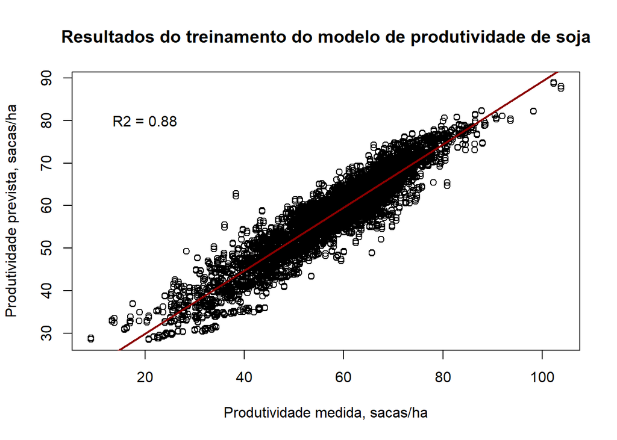

```r
## Not run (may take some time some complete)
# modelLookup("rf")
# grid <- expand.grid(.mtry=seq(6, 34, length.out = 5))
#
# cl <- makeCluster(detectCores() - 1) # 1 núcleo fica pro SO
# registerDoParallel(cl)
# ctrl <- trainControl(method = "cv", number = 5,
#                      selectionFunction = "oneSE", allowParallel = TRUE)
# rf <- train(productivity ~ ., data = soja, method = "rf",
#             tuneGrid = grid, trControl = ctrl)
#
# stopCluster(cl)
# registerDoSEQ()
#
# saveRDS(rf, "rf_soja4.rds")
## End (Not run)
# rf <- read_rds("rf_soja4.rds")
rf <- readRDS("rf_soja4.rds")
prod.pred <- predict(rf)
plot(prod.pred ~ soja$productivity,
     xlab = "Produtividade medida, sacas/ha",
     ylab = "Produtividade prevista, sacas/ha",
     main = "Resultados do treinamento do modelo de produtividade de soja")
R2 <- cor(prod.pred, soja$productivity) ^ 2
abline(lm(prod.pred ~ soja$productivity), lwd = 2, col = "darkred")
text(20, 80, paste0("R2 = ", round(R2, 2)))
```

```r
MAE <- function(actuals, pred) {
  mean(abs(actuals - pred))
}
dma <- MAE(soja$productivity, prod.pred)
cat("Erro médio absoluto: ", round(dma, 1), " sacas/ha")
```

```
Erro médio absoluto:  3.6  sacas/ha
```

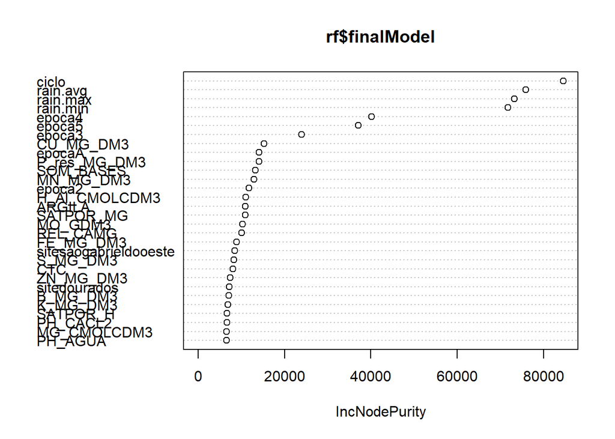

```r
randomForest::varImpPlot(rf$finalModel)
```

Como se vê, a acurácia do modelo é bastante boa, com R<sup>2</sup> e erro médio absoluto em níveis bastante aceitáveis.

## Importância relativa das variáveis para cada tipo de semente

A última etapa do projeto consiste em determinar, para cada tipo de semente, qual a importância relativa das demais variáveis na estimativa de produtividade, para fins de informação e orientação a pesquisas posteriores da FMS.

Para resolver esse problema, antes de mais nada, temos de verificar de quantos tipos diferentes de sementes estamos a falar. Vejamos:

```r
seeds <- length(unique(soja$material))
cat("Quantidade de tipos de sementes: ", seeds, " tipos.")
```

```
Quantidade de tipos de sementes:  154  tipos.
```

```r
seeds <- unique(soja$material) %>% as.character()
head(seeds)
```

```
[1] "5d600rr" "5d615rr" "5d634rr" "5g685rr" "97r21rr" "97y07rr"
```

Portanto, temos de treinar 154 diferentes modelos, um para cada semente, e depois determinar a importância relativa das demais variáveis para cada modelo correspondente. Resta evidente que, pelo baixo número de participação de cada tipo de semente no *dataset* final, faz-se desnecessário usar `random forest` para cada semente. Nossa abordagem consiste em treinar um modelo mais simples para cada semente e então determinar a importância relativa das variáveis, medida como o fator pelo qual o erro de previsão do modelo aumenta quando a variável é “embaralhada” no *dataframe* original.

```r
## Not run (this may take some time to complete)
# FeatImpPerSeed <- function(seed, plt = F) {
#   if (!Xmisc::is.package.loaded("rpart")) {
#     require(rpart)
#   }
#   data <- filter(soja, material == seed)
#   data$material <- NULL
#   tree <- rpart(productivity ~ ., data = data)
#   y <- data$productivity
#   X <- data[-which(names(data) == "productivity")]
#   mod <- Predictor$new(tree, data = X, y = y)
  # Compute feature importances as the performance drop in mean absolute error
  # imp <- FeatureImp$new(mod, loss = "mae")
  # Plot the results directly
#   if (plt) plot(imp)
#   return(imp$results)
# }
#
# imp <- lapply(seeds, FeatImpPerSeed)
# saveRDS(imp, "feature_imp_per_seed.rds")
#
# for (i in seq_along(seeds)) {
#   imp[[i]]$material <- seeds[i]
# }
# imp[[1]]
# saveRDS(imp, "feature_imp_per_seed.rds")
## End (Not run)
imp <- readRDS("feature_imp_per_seed.rds")
var_imp_sementes <- rlist::list.stack(imp)
var_imp_sementes %<>% select(material, everything())
head(seeds, 10)
```

```
 [1] "5d600rr"     "5d615rr"     "5d634rr"     "5g685rr"     "97r21rr"
 [6] "97y07rr"     "adv4317ipro" "adv4341ipro" "as3590ipro"  "as3610ipro"
```

```r
DT::datatable(var_imp_sementes)
```

|  | material | feature | importance.05 | importance | importance.95 | permutation.error |
| --- | --- | --- | --- | --- | --- | --- |
| 1 | 5d600rr | site | 1.52964284046874 | 2.05562818058733 | 2.24270818743483 | 12.3331932773109 |
| 2 | 5d600rr | rain.min | 1.19215416219245 | 1.25467342079462 | 1.49702024682136 | 7.52768907563025 |
| 3 | 5d600rr | P_meh_MG_DM3 | 0.973664192228084 | 1.09759714894875 | 1.17320245265107 | 6.58527544351074 |
| 4 | 5d600rr | epoca | 1.00929906469334 | 1.07948939415161 | 1.13641564343184 | 6.47663398692811 |
| 5 | 5d600rr | ARGILA | 0.898958712669437 | 1.06146334251521 | 1.19844203744339 | 6.3684827264239 |
| 6 | 5d600rr | SATPOR_K | 0.993295049566584 | 1.05861151314254 | 1.11289556001681 | 6.35137254901961 |
| 7 | 5d600rr | rain.avg | 1.00086916600526 | 1.05593009321942 | 1.1247403395739 | 6.3352847805789 |
| 8 | 5d600rr | H_Al_CMOLCDM3 | 0.880889086013975 | 1.04778623340648 | 1.15201083150474 | 6.28642390289449 |
| 9 | 5d600rr | MG_CMOLCDM3 | 0.975917176338764 | 1.04156356505906 | 1.09006660752914 | 6.24908963585434 |
| 10 | 5d600rr | SAT_BASES | 0.932453740448511 | 1.02623994272997 | 1.09132919370652 | 6.15715219421102 |

[output cut: 5072 more lines]